# Hypothesis Testing in Healthcare: Drug Safety

[figure not shown]

#### This project was done in October, 2025.

[Image source](https://www.thomsonreuters.com/en-us/posts/technology/ai-usage-healthcare/)

## 📖 Background

Pharmaceutical drugs have become an essential part of our health. Therefore, they need to be safe with little or no adverse effects.

A pharmaceutical company, *GlobalXYZ*, has just completed a randomized controlled drug trial. To promote transparency and reproducibility of the drug's outcome, they (*GlobalXYZ*) have presented the dataset to your organization, a non-profit that focuses primarily on drug safety.

## 💾 The Data

The dataset provided contained five adverse effects, demographic data, vital signs, etc. Your organization is primarily interested in the drug's adverse reactions. It wants to know if the adverse reactions, if any, are of significant proportions. It has asked you to explore and answer some questions from the data.

The dataset `drug_safety.csv` was obtained from [Hbiostat](https://hbiostat.org/data/) courtesy of the Vanderbilt University Department of Biostatistics. It contained five adverse effects: headache, abdominal pain, dyspepsia, upper respiratory infection, chronic obstructive airway disease (COAD), demographic data, vital signs, lab measures, etc. The ratio of drug observations to placebo observations is 2 to 1.

For this project, the dataset has been modified to reflect the presence and absence of adverse effects (`adverse_effects`) and the number of adverse effects in a single individual (`num_effects`).

The columns in the modified dataset are:

| Column | Description |
| --- | --- |
| `sex` | The gender of the individual |
| `age` | The age of the individual |
| `trx` | The treatment (Drug) and control (Placebo) groups |
| `week` | The week of the drug testing |
| `wbc` | The count of white blood cells |
| `rbc` | The count of red blood cells |
| `adverse_effects` | The presence of at least a single adverse effect |
| `num_effects` | The number of adverse effects experienced by a single individual |

The original dataset can be found [here](https://hbiostat.org/data/repo/safety.rda).

# Objectives

You work with a non-profit that advocates for pharmaceutical drug safety. One of its tasks is to create reports on drugs independent of the drug manufacturer.  
Your organization has asked you to explore and answer some questions from the data collected. You'll conduct several hypothesis tests using Python to determine if the adverse reactions of a hypothetical drug are significant. You'll also check if factors such as age significantly influence the adverse reactions.

Perform hypothesis tests to determine if the adverse effects of a pharmaceutical drug are significant!

1) Determine if the proportion of adverse effects differs significantly between the Drug and Placebo groups, saving the p-value as a variable called `two_sample_p_value`. 2) Find out if the number of adverse effects is independent of the treatment and control groups, saving as a variable called `num_effects_p_value` containing a p-value. 3) Examine if there is a significant difference between the ages of the Drug and Placebo groups, storing the p-value of your test in a variable called `age_group_effects_p_value`.

# Summary of Findings & Recommendations

This project utilizes statistical techniques, primarily hypothesis tests, to evaluate some key objectives regarding individuals' health data & how it was impacted, if at all, by a new hypothetical drug that has been produced by *GlobalXYZ*. The company, in the interest of transparency, are seeking an evaluation of the validity & reproducibility of a drug trial they have recently completed. Moreover, they need to know if the drug is safe to use.  
Analyses were conducted using data provided to answer such inquiries. More specifically, control & treatment groups were analyzed in relation to whether individuals reported any adverse effects as well as how many they experienced. Other variables, such as peoples' ages, were also incorporated into the analyses.

In this project, there were three main sections for each of the primary objectives. Before analyses were conducted, however, the data was imported & explored at a basic level to gain an initial understanding & identify any inconsistencies that may require preprocessing.

- For clarity, the Drug & treatment groups refer to the same group of individuals, as do the Placebo & control groups.

### Preprocessing

Of the 16,103 individuals included in the experiment, nearly 7,000 of them did not have their white-blood-cell & red-blood-cell counts properly recorded. As such, a quick analysis of the distributions of these variables was conducted to determine what imputation method to utilize. For the white-blood-cell counts, there was enough of a skew such that the median was used, whereas the mean was used for the red-blood-cell counts because there was near-perfect symmetry in the distribution.

### Analysis I - Adverse Effects Between Drug/Placebo Groups

To evaluate how the new drug affected individuals across the treatment & control groups, proportions of individuals in each were analyzed according to whether they experienced adverse effects or not. Firstly, some standard analyses were performed including calculations & visuals. Across these two variables, the proportions were remarkably similar. Note that of the 16,103 individuals, 10,727 of them were in the treatment (drug) group & 5,376 were in the control (placebo) group, which is about a 2:1 ratio.

- The percentage of individuals (within each control/treatment group) who did not experience adverse effects was about 90.45% & 90.48% in the treatment & control groups respectively.

These figures indicate that there is not a significant difference in these proportions of individuals. Nonetheless, hypothesis testing was utilized to either reinforce or oppose this conclusion.

Given that this section evaluated proportions across two groups, a two-sample proportion z-test was used. In this case, the null hypothesis proposed that the proportion of people who experienced adverse effects was equivalent between the treatment & control groups. The alternative hypothesis suggested that the proportions were different.

- The hypothesis test obtained a p-value of 0.96. Typically, significance levels are set no higher than 10%. As such, this test indicates that there is no significant evidence from which the null hypothesis can be rejected. Therefore, there is not a significant difference in the proportion of individuals who experienced adverse effects from the drug between the drug & placebo groups.

### Analysis II - Number of Adverse Effects Between Drug/Placebo Groups

To determine if the drug influenced the number of adverse effects that individuals experienced, the number of effects was analyzed across the treatment & control groups. Once more, some straightforward analyses were performed, the results of which came to similar conclusions as in **Analysis I**. That is, the proportions of individuals across each number of adverse effects were very similar. For example, the percentage of people (within each treatment/control group) who experienced one adverse effect was approximately 8.91% & 9.04% for the treatment & control groups respectively.

To further substantiate these findings, a chi-square hypothesis test was used. It was used because the goal was to determine if the number of adverse effects is independent of the treatment and control groups. Chi-square tests are often used to assess whether two categorical variables are independent or not.  
In this case, the null hypothesis proposed that the number of adverse effects experienced is independent of the group that an individual was in. Conversely, the alternative hypothesis suggested that these variables are *not* independent.

- The smallest p-value obtained from the hypothesis test was about 0.50, which is much greater than a typical significance level of five or ten percent. As such, this test indicates that there is no significant evidence from which the null hypothesis can be rejected. Therefore, the number of adverse effects experienced from using the drug is independent of whether an individual is in the control or treatment group.

### Analysis III - Ages Across Drug/Placebo Groups

Finally, the ages of the involved individuals were analyzed across the treatment/control groups to assess whether the drug impacted people differently according to their age. A brief analysis of ages across these two groups revealed quite similar averages & distributions. The average ages were about 64 years in each group.

Given the nature of the data, a Mann-Whitney U test was used to further quantify this inquiry. The null hypothesis stated that there is not a significant difference between the ages of the treatment & control groups. Naturally, the alternative hypothesis stated there *is* a significant difference.

- The resulting p-value was about 0.26 which is noticeably larger than the pre-established significance level of ten percent. As such, this test failed to find substantial evidence with which to reject the null hypothesis. In other words, there is no significant difference between the ages of individuals in the treatment & control groups.

### Recommendations

- Obviously, the nature of the drug should still be taken into account when it comes to who may be directed/allowed to take this drug. For instance, giving a new drug to young children is likely not a wise decision given that their bodies are still maturing.

## Importing, Preprocessing, Exploratory Data Analysis

Before any statistical analyses or hypothesis tests are run, the data needs to be imported & checked for inconstencies that could impede the validity of such analyses. Moreover, initial exploration of the dataset can be done to get a basic understanding of the data within, particularly the primary variables of interest.

```python
#need to install the 'pingouin' module into the local environment
!pip install pingouin
```

```python
import numpy as np
import pandas as pd
from statsmodels.stats.proportion import proportions_ztest
import pingouin
from scipy import stats
import statsmodels.api as sm

import matplotlib.pyplot as plt
import seaborn as sns
```

```python
#Import the data
orig_df = pd.read_csv('drug_safety.csv')

#Inspect the data
display(orig_df.sample(5))
display(orig_df.info())
display(orig_df.isna().sum())
```

|  | age | sex | trx | week | wbc | rbc | adverse_effects | num_effects |
| --- | --- | --- | --- | --- | --- | --- | --- | --- |
| 2660 | 64 | female | Drug | 4 | 7.8 | 4.1 | No | 0 |
| 7792 | 78 | female | Drug | 2 | NaN | NaN | No | 0 |
| 10495 | 71 | male | Drug | 0 | 10.4 | 5.0 | No | 0 |
| 7674 | 67 | male | Drug | 20 | NaN | NaN | No | 0 |
| 624 | 77 | female | Placebo | 1 | NaN | NaN | Yes | 1 |

```
<class 'pandas.core.frame.DataFrame'>
RangeIndex: 16103 entries, 0 to 16102
Data columns (total 8 columns):
 #   Column           Non-Null Count  Dtype
---  ------           --------------  -----
 0   age              16103 non-null  int64
 1   sex              16103 non-null  object
 2   trx              16103 non-null  object
 3   week             16103 non-null  int64
 4   wbc              9128 non-null   float64
 5   rbc              9127 non-null   float64
 6   adverse_effects  16103 non-null  object
 7   num_effects      16103 non-null  int64
dtypes: float64(2), int64(3), object(3)
memory usage: 1006.6+ KB
```

```
None
```

```
age                   0
sex                   0
trx                   0
week                  0
wbc                6975
rbc                6976
adverse_effects       0
num_effects           0
dtype: int64
```

```python
#Inspect values of each variable
display(orig_df.iloc[:,7].value_counts(dropna=False).sort_index())
```

```
num_effects
0    14567
1     1442
2       88
3        6
Name: count, dtype: int64
```

In the dataset, there are 16,103 observations & eight variables. Two variables have missing values; 'wbc' & 'rbc' have 6,975 & 6,976 missing values respectively. A breakdown of the values of each variable are listed below.

- **Age:**
  - There are no missing values. Span 39-84 years.
- **Sex:**
  - There are no missing values. There are 12,328 males & 3,775 females, about a 3.3:1 ratio (or ~ 10:3).
- **Treatment/Control Group:**
  - There are no missing values. There are 10,727 people in the "Drug" group & 5,376 in the "Placebo" group, nearly a 2:1 ratio.
- **Week:**
  - There are no missing values. There are eight unique weeks spanning 0-20, each of which has about 2,000 observations.
- **White Blood Cells:**
  - There are 6,975 missing values. The values span 1.80-26.5. The missing values could be imputed with the mean or median depending on the shape of the distribution.
- **Red Blood Cells:**
  - There are 6,976 missing values. The values span 2.1-7.6. The missing values could be imputed with the mean or median depending on the shape of the distribution.
- **Adverse Effects:**
  - There are no missing values. There are 1,536 people with adverse effects & 14,567 people without adverse effects. In other words, for every 100 individuals, approximately 90 did not experience adverse effects whereas about 10 did.
- **Number Effects:**
  - There are no missing values. The 16,103 individuals experienced somewhere between zero & three adverse effects; 1,442 people had one, 88 had two, & six had three. In other words, for every 100 people, roughly 90 experienced none, about nine experienced one, & one experienced two. Cases of three adverse effects were very rare (less than 0.04%).

With an elementary understanding of the variables, the only preprocessing step that needs to be considered is what to do with the missing values in the 'wbc' & 'rbc' variables. Firstly, these variables are missing around 43 percent of the data points, dropping them is not appropriate. Given that they are numerical in nature, imputing them using an aggregate metric, such as the mean or median, would be acceptable. To determine which, their distributions should be analyzed to check for the presence of extreme values. Outliers are more influential to the mean of a variable than the median so if there are such values, the median would be more appropriate for imputation purposes.

- Ultimately, these variables ('wbc', 'rbc') will not be used in the analyses of this project; however, performing the imputations is still a benficial exercise in case such analyses are ever conducted.

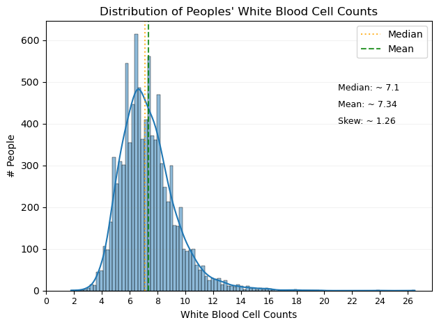

```python
#Visualize distribution of the white blood cells

ax1 = sns.histplot(data=orig_df, x='wbc', kde=True)
#plot the median, mean, skew
plt.axvline(x=orig_df['wbc'].median(), color='orange', linestyle=':', alpha=0.8, label='Median')
plt.axvline(x=orig_df['wbc'].mean(), color='green', linestyle='--', alpha=0.8, label='Mean')
plt.annotate(text=f"Median: ~ {np.round(orig_df['wbc'].median(), 2)}", xy=(21,480), fontsize=9)
plt.annotate(text=f"Mean: ~ {np.round(orig_df['wbc'].mean(), 2)}", xy=(21,440), fontsize=9)
plt.annotate(text=f"Skew: ~ {np.round(orig_df['wbc'].skew(), 2)}", xy=(21,400), fontsize=9)
#edit plot details
plt.title("Distribution of Peoples' White Blood Cell Counts")
plt.xlabel('White Blood Cell Counts')
plt.xticks(fontsize=9, ticks=range(0,27,2))
plt.ylabel('# People')
plt.legend()
plt.grid(axis='y',alpha=0.1,color='gray')
plt.tight_layout();
```

The figure above illustrates the distribution of the number of white blood cells that were measured from people in the drug trial. For clarity, the orange, dotted line & green, dashed line indicate the median & mean respectively of this distribution. In this experiment, there were 16,103 individuals; however, 6,975 of them did not have a measurement. This visual was built to evaluate the shape of the distribution of this variable in order to determine what metric to use when imputing the missing values.

From this figure, there is a clear positive skew where there are more extreme values on the right side of the distribution. Moreover, the white-blood-cell-count variable has a skew of about 1.26, indicating a significant, positive skew. As such, the median would be more appropriate when imputing the missing values of this variable.

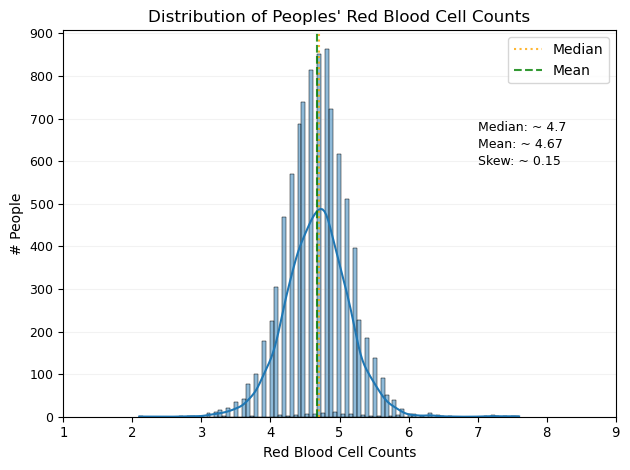

```python
#Visualize distribution of the red blood cells

ax2 = sns.histplot(data=orig_df, x='rbc', kde=True)
#plot the median, mean, skew
plt.axvline(x=orig_df['rbc'].median(), color='orange', linestyle=':', alpha=0.8, label='Median')
plt.axvline(x=orig_df['rbc'].mean(), color='green', linestyle='--', alpha=0.8, label='Mean')
plt.annotate(text=f"Median: ~ {np.round(orig_df['rbc'].median(), 2)}", xy=(7,670), fontsize=9)
plt.annotate(text=f"Mean: ~ {np.round(orig_df['rbc'].mean(), 2)}", xy=(7,630), fontsize=9)
plt.annotate(text=f"Skew: ~ {np.round(orig_df['rbc'].skew(), 2)}", xy=(7,590), fontsize=9)
#edit plot details
plt.title("Distribution of Peoples' Red Blood Cell Counts")
plt.xlabel('Red Blood Cell Counts')
plt.xticks(fontsize=9.5, ticks=range(1,10,1))
plt.ylabel('# People')
plt.yticks(ticks=range(0,901,100), fontsize=9)
plt.legend()
plt.grid(axis='y',alpha=0.1,color='gray')
plt.tight_layout();
```

The figure above illustrates the distribution of the number of red blood cells that were measured from people in the drug trial. For clarity, the orange, dotted line & green, dashed line indicate the median & mean respectively of this distribution. In this experiment, there were 16,103 individuals; however, 6,976 of them did not have a measurement. This visual was built to evaluate the shape of the distribution of this variable in order to determine what metric to use when imputing the missing values.

From this figure, there is not a clear skew in either direction in the distribution. Moreover, the red-blood-cell-count variable has a skew of about 0.15, indicating a very small, positive skew. Given the near-symmetry of this figure, the mean would be acceptable when imputing the missing values of this variable.

```python
#Impute the missing values for 'wbc', 'rbc'

#make a copy of the original dataset to avoid modifying it
cl_df = orig_df.copy()

#Impute 'wbc'/'rbc' using the median/mean
cl_df = cl_df.fillna({'wbc':cl_df['wbc'].median(), 'rbc':cl_df['rbc'].mean()})

#Check the output
display(cl_df.isna().sum())
```

```
age                0
sex                0
trx                0
week               0
wbc                0
rbc                0
adverse_effects    0
num_effects        0
dtype: int64
```

Now that missing values have been handled, analyses can be conducted.

# Analysis I - Adverse Effects Between Drug/Placebo Groups

**Determine if the proportion of adverse effects differs significantly between the Drug & Placebo groups, saving the p-value as a variable called `two_sample_p_value`.**

This section will evaluate if there is a significant difference between the proportions of individuals across the drug (treatment) & placebo (control) groups who experienced adverse effects. To start, a brief, exploratory analysis can be performed to get an initial evaluation of these variables.

|  | trx | adverse_effects | # | % per trx group |
| --- | --- | --- | --- | --- |
| 0 | Drug | No | 9703 | 90.45 |
| 1 | Drug | Yes | 1024 | 9.55 |
| 2 | Placebo | No | 4864 | 90.48 |
| 3 | Placebo | Yes | 512 | 9.52 |

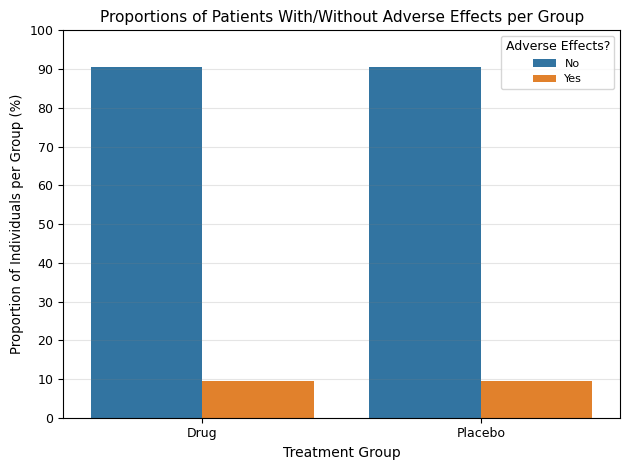

```python
#Calculate, inspect the ratios between 'trx' & 'adverse_effects'
trx_adv_eff_splits = orig_df.groupby(['trx','adverse_effects']).age.count().reset_index().rename(columns={'age':'#'})

#Want to add a variable indicating the percentage of individuals per 'trx' group
#retrieve the # individuals per 'trx' group
num_Drug_grp = orig_df[orig_df['trx'] == 'Drug'].shape[0]
num_Plac_grp = orig_df[orig_df['trx'] == 'Placebo'].shape[0]
#perform arithmetic; divide '#' by # individuals per 'trx' group, convert to a %
perc_Drug_grp = [np.round(100*i/num_Drug_grp,2) for i in trx_adv_eff_splits[trx_adv_eff_splits.trx == 'Drug']['#'].values]
perc_Plac_grp = [np.round(100*i/num_Plac_grp,2) for i in trx_adv_eff_splits[trx_adv_eff_splits.trx == 'Placebo']['#'].values]
#Create the new variable
trx_adv_eff_splits['% per trx group'] = perc_Drug_grp + perc_Plac_grp
#Check the results
display(trx_adv_eff_splits)


#Visualize the data
ax1 = sns.barplot(data=trx_adv_eff_splits, x='trx', y='% per trx group', hue='adverse_effects')
#edit plot details
plt.title('Proportions of Patients With/Without Adverse Effects per Group', fontsize=11)
plt.xlabel('Treatment Group')
plt.xticks(fontsize=9)
plt.ylabel('Proportion of Individuals per Group (%)', fontsize=9.5)
ax1.set(ylim=(0,100))
plt.yticks(ticks=range(0,101,10), fontsize=9)
plt.legend(title='Adverse Effects?', title_fontsize=9, fontsize=8, loc='upper right')
plt.grid(axis='y',alpha=0.2,color='gray')
plt.tight_layout();
```

The figure above illustrates the percentage of individuals who have experienced adverse effects from the drugs they took in the experimental trial based on what treatment group they were in.

Recall that in this trial, there were about two people in the "Drug" group for every one person in the "Placebo" group. Nonetheless, the proportions of individuals across the two treatment groups appear to be very similar. The proportion of people who experienced adverse effects was about 9.55% & 9.52% for those in the drug & placebo group respectively.  
As such, this figure suggests that there is no significant difference in the proportion of people who experienced adverse effects between the drug & placebo groups. Nevertheless, hypothesis testing can be utilized to evaluate this further.

Given the goal of this section, it would be appropriate to use a two-sample proportion z-test which tests for equality between proportions across two groups.

- Such a test requires the groups to be independent. Given that the pharmaceutical company performed a randomized, controlled trial where the patients were only part of either the "Drug" or "Placebo" group, it can be said that the two groups are independent.
- Each group needs to have a reasonably large sample size. The "Drug" & "Placebo" groups recorded data for about 10,700 & 5,400 individuals respectively which are sufficient.

In this case, the null & alternative hypotheses follow as:

- $H_0$: The proportion of people who experienced adverse effects was equivalent between the Drug & Placebo groups.
- $H_A$: The proportion of people who experienced adverse effects was different between the Drug & Placebo groups.

Here, the `proportions_ztest` function from the statsmodels package is useful. It has the following arguments.

- The number of relevant observations in each group; the `count` parameter. In this case, this quantifies the number of patients who experienced adverse effects in the Drug & Placebo groups.
- The number of total observations in each group; the `nobs` parameter. In this case, this quantifies the number of total patients in the Drug & Placebo groups.
- Use a 'two-sided' hypothesis test because the desire is to determine if there is a difference in general between the two groups, & not a difference in a specific direction.

```python
#Obtain the # individuals with adverse effects in each 'trx' group
num_adveffs_trx = orig_df[orig_df.adverse_effects == 'Yes'].trx.value_counts(dropna=False)

#Obtain the # individuals in each 'trx' group
#display(orig_df.trx.value_counts().values)

#Perform hypothesis test
z_score, two_sample_p_value = proportions_ztest(count=num_adveffs_trx.values, nobs=orig_df.trx.value_counts().values,
                                     alternative='two-sided')
#Retrieve the coefficients
display(f"Z-score: {z_score}", f"P-value: {two_sample_p_value}")
```

```
'Z-score: 0.0452182684494942'
```

```
'P-value: 0.9639333330262475'
```

The resulting z-score & p-value are 0.045 & 0.964 respectively. In hypothesis testing, the significance level, also known as alpha, is usually set no higher than 0.10. With the p-value being so much greater than this threshold, it is a clear indication that there is not sufficient evidence from which the null hypothesis can be rejected.

> As such, there is not a significant difference in the proportion of individuals who experienced adverse effects from the drugs between the Drug & Placebo groups.

# Analysis II - Number of Adverse Effects Between Drug/Placebo Groups

**Find out if the number of adverse effects is independent of the treatment and control groups, saving as a variable called `num_effects_p_value` containing a p-value.**

This section will evaluate if there is a significant relationship between the number of adverse effects experienced by individuals & the treatment (drug) & control (placebo) groups. To start, a brief, exploratory analysis can be performed to get an initial evaluation of these variables.

- Keep in mind the number of individuals in each group: 10,727 in the treatment & 5,376 in the control (about a 2:1 ratio).

```python
#Obtain the # individuals per 'trx' & 'num_effects'
num_trx_numeff = orig_df.groupby(['trx','num_effects'])['age'].count().reset_index().rename(columns={'age':'#'})

#Want to add the proportions per 'trx' group
#calculate the proportions for the Drug, Placebo groups
prop_Drug_numeff = orig_df[orig_df.trx == 'Drug'][['trx','num_effects']].value_counts(normalize=True).reset_index()
prop_Plac_numeff = orig_df[orig_df.trx == 'Placebo'][['trx','num_effects']].value_counts(normalize=True).reset_index()
#merge the data, then append to the first dataset
trx_numeff_splits = num_trx_numeff.merge(pd.concat([prop_Drug_numeff, prop_Plac_numeff], axis=0),
                                         on=['trx','num_effects']).rename(columns={'proportion':'% per trx group'})
#Change the new variable to a %
trx_numeff_splits['% per trx group'] = np.round(trx_numeff_splits['% per trx group']*100,2)

#Check the results
display(trx_numeff_splits.sort_values(['num_effects','trx']).reset_index(drop=True))
```

|  | trx | num_effects | # | % per trx group |
| --- | --- | --- | --- | --- |
| 0 | Drug | 0 | 9703 | 90.45 |
| 1 | Placebo | 0 | 4864 | 90.48 |
| 2 | Drug | 1 | 956 | 8.91 |
| 3 | Placebo | 1 | 486 | 9.04 |
| 4 | Drug | 2 | 63 | 0.59 |
| 5 | Placebo | 2 | 25 | 0.47 |
| 6 | Drug | 3 | 5 | 0.05 |
| 7 | Placebo | 3 | 1 | 0.02 |

Since there are uneven quantities in the two groups (drug vs placebo), comparative analyses need to be performed. In other words, obtaining proportions across the 'trx' & 'num_effects' variables will be beneficial.

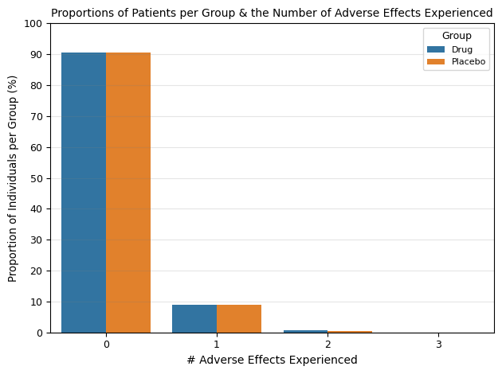

```python
#Illustrate the # adverse effects across 'trx'
ax1 = sns.barplot(data=trx_numeff_splits, x='num_effects', y='% per trx group', hue='trx')

#edit plot details
plt.title('Proportions of Patients per Group & the Number of Adverse Effects Experienced', fontsize=10)
plt.xlabel('# Adverse Effects Experienced')
plt.xticks(fontsize=9)
plt.ylabel('Proportion of Individuals per Group (%)', fontsize=9.5)
ax1.set(ylim=(0,100))
plt.yticks(ticks=range(0,101,10), fontsize=9)
plt.legend(title='Group', title_fontsize=9, fontsize=8, loc='upper right')
plt.grid(axis='y',alpha=0.2,color='gray')
plt.tight_layout();
```

The figure above illustrates the proportion of patients per group & the number of adverse effects they experienced from the drug usage.

Recall that in this trial, there were about two people in the "Drug" group for every one person in the "Placebo" group. Nonetheless, the proportions of individuals across the two treatment groups appear to be very similar. For example, the proportion of people who experienced one adverse effect was about 8.91% & 9.04% for those in the drug & placebo group respectively.  
As such, this figure suggests that the group that a patient was in did not have a significant effect on the number of adverse effects they experienced. Nevertheless, hypothesis testing can be utilized to evaluate this further.

This section is seeking to determine whether the group that a patient is in (the 'trx' variable) has an effect on the number of adverse effects they experience from the drug usage. In other words, are the 'trx' & 'num_effects' variables related. Such an inquiry can be measured with a chi-square test which is often used to evaluate whether two categorical variables are independent or not.

In this case, the null & alternative hypotheses follow as:

- $H_0$: The number of adverse effects experienced is independent of the group that the patient was in.
- $H_A$: The number of adverse effects experienced is *not* independent of the group that the patient was in.

```python
#Perform the hypothesis test
expected, observed, stats = pingouin.chi2_independence(data=orig_df, x='num_effects', y='trx', correction=False)
display(stats)

#Assign the specified variable (in DataCamp)
num_effects_p_value = stats.loc[0,'pval']
#display(num_effects_p_value)
```

|  | test | lambda | chi2 | dof | pval | cramer | power |
| --- | --- | --- | --- | --- | --- | --- | --- |
| 0 | pearson | 1.000000 | 1.799644 | 3.0 | 0.615012 | 0.010572 | 0.176275 |
| 1 | cressie-read | 0.666667 | 1.836006 | 3.0 | 0.607131 | 0.010678 | 0.179153 |
| 2 | log-likelihood | 0.000000 | 1.922495 | 3.0 | 0.588648 | 0.010926 | 0.186033 |
| 3 | freeman-tukey | -0.500000 | 2.001752 | 3.0 | 0.572043 | 0.011149 | 0.192379 |
| 4 | mod-log-likelihood | -1.000000 | 2.096158 | 3.0 | 0.552690 | 0.011409 | 0.199984 |
| 5 | neyman | -2.000000 | 2.344303 | 3.0 | 0.504087 | 0.012066 | 0.220189 |

Even if a relatively large significance level of 0.10 is used for this hypothesis test of independence, the p-values in these results, the smallest of which is about 0.50, are still significantly larger. Therefore, there is not sufficient evidence from which the null hypothesis can be rejected.

> As such, the number of adverse effects experienced from the drug usage is independent of whether the patient was in the control (Placebo) or treatment (Drug) group.

# Analysis III - Ages Across Drug/Placebo Groups

**Examine if there is a significant difference between the ages of the Drug and Placebo groups, storing the p-value of your test in a variable called `age_group_effects_p_value`.**

This section will evaluate if there is a significant difference between the ages of the individuals in the treatment (drug) & control (placebo) groups. To start, a brief, exploratory analysis can be performed to get an initial evaluation of these variables.

- Keep in mind the number of individuals in each group: 10,727 in the treatment & 5,376 in the control (about a 2:1 ratio).

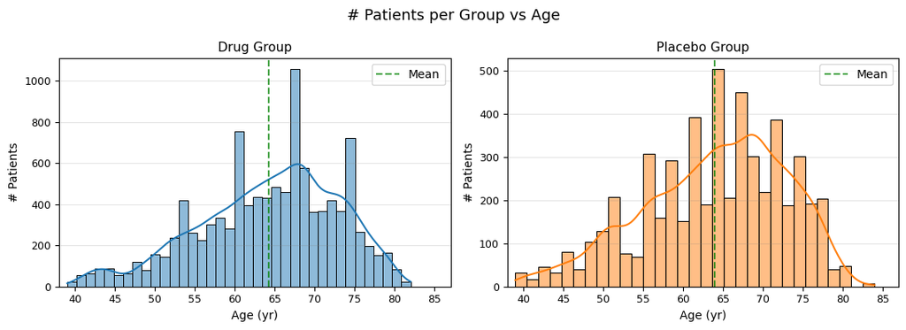

```python
#Visualize ages per 'trx' group
fig, axes = plt.subplots(ncols=2, figsize=(11,4), sharey=False)
#Drug Group
ax1 = sns.histplot(data=orig_df[orig_df.trx == 'Drug'], x='age', ax=axes[0], color=sns.color_palette()[0], kde=True)
#add the mean
ax1.axvline(x=orig_df[orig_df.trx == 'Drug']['age'].mean(), color='green', linestyle='--', alpha=0.7, label='Mean')
#Placebo Group
ax2 = sns.histplot(data=orig_df[orig_df.trx == 'Placebo'], x='age', ax=axes[1], color=sns.color_palette()[1], kde=True)
#add the mean
ax2.axvline(x=orig_df[orig_df.trx == 'Placebo']['age'].mean(), color='green', linestyle='--', alpha=0.7, label='Mean')

#edit plot details
fig.suptitle('# Patients per Group vs Age', fontsize=13)
for k, v in {'Drug Group':[0], 'Placebo Group':[1]}.items():
    plt.sca(axes[v[0]])
    plt.title(k, fontsize=11)
    plt.xlabel('Age (yr)')
    plt.xticks(fontsize=9, ticks=range(40,86,5))
    axes[v[0]].set(xlim=(38,87))
    plt.ylabel('# Patients')
    plt.yticks(fontsize=9)
    plt.legend()
    plt.grid(axis='y', alpha=0.2, color='gray')
    plt.tight_layout();
```

The figures above demonstrates the distributions of ages of patients based on the trial group they were in; the Drug or Placebo group. The vertical, dashed, green lines indicate the average age for each group of patients. Note that the vertical axes of the two plots are *not* the same--that of the drug group is approximately twice as tall as that of the placebo group. This was done to help compare the overall shapes of the distributions.

Recall that in this trial, there were about two patients in the Drug group for every one patient in the Placebo group. The two groups have an average age of about 64 years. Generally, they appear to be quite similar in these plots since there are no major differences between them. As such, it is difficult to discern a significant difference in the ages of these patients across the two groups.

When performing hypothesis testing with numerical variables, evaluating their distributions can help to determine what kind of test is most appropriate. For example, parametric tests rely on the data being normally distributed, whereas non-parametric tests allow for exceptions to this.  
In this case, both of these two age distributions are close to, but not quite normal. There is a clear single peak near the midpoint of the age range, but neither of the distributions are symmetrical around the mean in the way that a true normal distribution would appear. Since the mean age is less than the mode of the age (the peak), the data are slightly left-skewed.  
As such, a non-parametric hypothesis test would be more appropriate with these variables.

- To evaluate the normality of these distributions further, other tests & visualizations could be used like a Q-Q plot.

Other factors to consider when choosing a hypothesis test include whether the data are independent or not, if there are clear outliers, or if the sample size is small. In this case, there are no signifcant outliers. Moreover, the two groups, which account for more than 5,000 observations each, are independent because every patient was only in one group & not both.  
Given this information, a Mann-Whitney U test could be appropriate for this data.

The `mwu` function from the pingouin package can be used to perform such a test. It has the following arguments.

- The `x` & `y` parameters take the numerical data from the two groups respectively.
- The `alternative` parameter specifies what kind of hypothesis test is being performed; one-tailed vs two-tailed. In this case, a two-tailed test is applicable because the objective pertains to whether there is a significant difference between the ages of the two groups.

Once more, take a significance value of 0.10. The null & alternative hypotheses are as follows.

- $H_0$: There is not a significant difference between the ages of the Drug & Placebo groups.
- $H_A$: There is a significant difference between the ages of the Drug & Placebo groups.

```python
#Perform the hypothesis test
mwu_test = pingouin.mwu(x=orig_df[orig_df.trx == 'Drug']['age'], y=orig_df[orig_df.trx == 'Placebo']['age'],
                        alternative='two-sided')
#check the results
display(mwu_test)

#Retrieve the desired value (DataCamp)
age_group_effects_p_value = mwu_test['p-val'][0]
#display(age_group_effects_p_value)
```

|  | U-val | alternative | p-val | RBC | CLES |
| --- | --- | --- | --- | --- | --- |
| MWU | 29149339.5 | two-sided | 0.256963 | 0.01093 | 0.505465 |

This hypothesis test calculated a p-value of about 0.26, which is noticeably greater than the preestablished significance level of 0.10. Therefore, there is not sufficient evidence with which to reject the null hypothesis.

> As such, there is not a significant difference between the ages of the Drug & Placebo groups.